# regression

## Expected value of Y given X

- E(Y|X)
- The regression of Y (DV) on X (IV) corresponds to the line that gives the mean value of Y corresponding to each possible value of X
- “Our best guess” regardless of whether our model includes categories or continuous

## Regression Equation

\[ Y = b_{0} + b_{1}X +e \] \[ \hat{Y} = b_{0} + b_{1}X \]

## OLS

- Ordinary Least Squares (OLS) estimation
- Minimizes deviations

\[ min\sum(Y_{i}-\hat{Y})^{2} \]

- Other estimation procedures possible (and necessary in some cases)

## Regression coefficient

\[ b_{1} = \frac{cov_{XY}}{s_{x}^{2}} = r_{xy} \frac{s_{y}}{s_{x}} \]

## Interpretation

- The regression coefficient (slope) equals the estimated change in Y for a 1-unit change in X
- For nominal variables using dummy coding (0 and 1s) the regression coefficient equals the difference in means between the two groups

## Standardized regression

- Regression using z-scores for Y and X
- Correlation equals standardized regression coefficent \[ b_{1} = r_{xy} \frac{s_{y}}{s_{x}} \] \[ r_{xy} = b_{1} \frac{s_{x}}{s_{y}} \] \[ \beta_{yx} = b_{yx}^{*} = r_{xy} \]

## Standardized regression equation

\[ Y = b_{1}^{*}X + e \] - Interpretation?

## Raw score regression equation

- intercept serves to adjust for differences in means between X and Y

\[ \hat{Y} = \bar{Y} + r_{xy} \frac{s_{y}}{s_{x}}(X-\bar{X}) \] - if standardized, intercept drops out  
- otherwise, intercept is where regression line crosses the y-axis at X = 0 - Also, notice that when X = \(\bar{X}\) the regression line goes through \(\bar{Y}\)

## Example

```r
fit.1 <- lm(parent ~ child, data = galton.data)
anova(fit.1)
```

```
## Analysis of Variance Table
##
## Response: parent
##            Df  Sum Sq Mean Sq F value    Pr(>F)
## child       1  623.26  623.26  246.84 < 2.2e-16 ***
## Residuals 926 2338.10    2.52
## ---
## Signif. codes:  0 '***' 0.001 '**' 0.01 '*' 0.05 '.' 0.1 ' ' 1
```

```r
summary(fit.1)
```

```
##
## Call:
## lm(formula = parent ~ child, data = galton.data)
##
## Residuals:
##     Min      1Q  Median      3Q     Max
## -4.6702 -1.1702 -0.1471  1.1324  4.2722
##
## Coefficients:
##             Estimate Std. Error t value Pr(>|t|)
## (Intercept) 46.13535    1.41225   32.67   <2e-16 ***
## child        0.32565    0.02073   15.71   <2e-16 ***
## ---
## Signif. codes:  0 '***' 0.001 '**' 0.01 '*' 0.05 '.' 0.1 ' ' 1
##
## Residual standard error: 1.589 on 926 degrees of freedom
## Multiple R-squared:  0.2105, Adjusted R-squared:  0.2096
## F-statistic: 246.8 on 1 and 926 DF,  p-value: < 2.2e-16
```

```r
library(psych)
describe(galton.data$parent)
```

```
##    vars   n  mean   sd median trimmed  mad min max range  skew kurtosis
## X1    1 928 68.31 1.79   68.5   68.32 1.48  64  73     9 -0.04     0.05
##      se
## X1 0.06
```

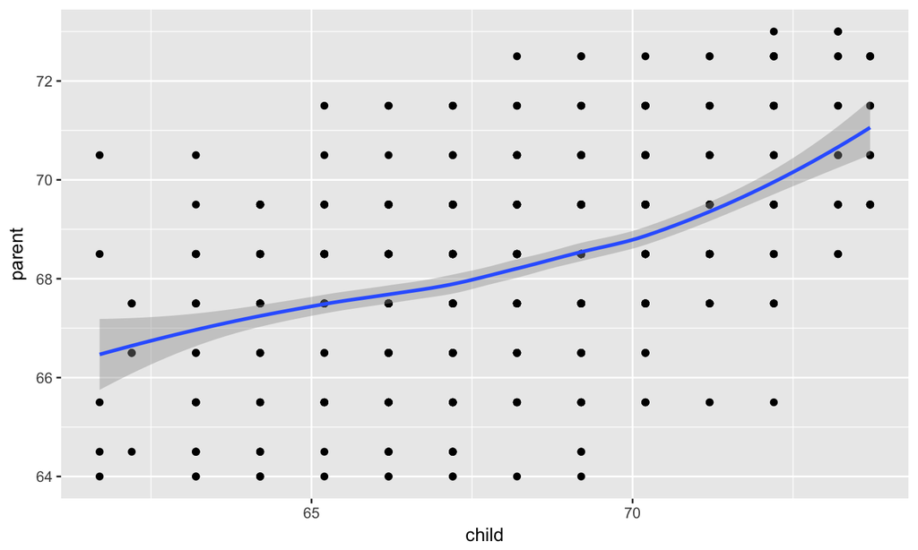

## ANOVA table

```r
anova(fit.1)
```

```
## Analysis of Variance Table
##
## Response: parent
##            Df  Sum Sq Mean Sq F value    Pr(>F)
## child       1  623.26  623.26  246.84 < 2.2e-16 ***
## Residuals 926 2338.10    2.52
## ---
## Signif. codes:  0 '***' 0.001 '**' 0.01 '*' 0.05 '.' 0.1 ' ' 1
```

## Exploring the lm object

```r
library(broom)
galton.data.1 <- augment(fit.1, galton.data)
head(galton.data.1)
```

```
##   parent child  .fitted   .se.fit     .resid        .hat   .sigma
## 1   70.5  61.7 66.22780 0.1423187  4.2721996 0.008021794 1.583599
## 2   68.5  61.7 66.22780 0.1423187  2.2721996 0.008021794 1.588097
## 3   65.5  61.7 66.22780 0.1423187 -0.7278004 0.008021794 1.589686
## 4   64.5  61.7 66.22780 0.1423187 -1.7278004 0.008021794 1.588844
## 5   64.0  61.7 66.22780 0.1423187 -2.2278004 0.008021794 1.588165
## 6   67.5  62.2 66.39062 0.1327306  1.1093758 0.006977341 1.589446
##        .cooksd .std.resid
## 1 0.0294637423  2.6994436
## 2 0.0083344662  1.4357182
## 3 0.0008550854 -0.4598700
## 4 0.0048191674 -1.0917327
## 5 0.0080119350 -1.4076640
## 6 0.0017244340  0.7006045
```

## fitted values, Y-hats

```r
psych::describe(galton.data.1$.fitted)
```

```
##    vars   n  mean   sd median trimmed  mad   min   max range  skew
## X1    1 928 68.31 0.82  68.34   68.32 0.97 66.23 70.14  3.91 -0.09
##    kurtosis   se
## X1    -0.35 0.03
```

```r
psych::describe(galton.data.1$parent)
```

```
##    vars   n  mean   sd median trimmed  mad min max range  skew kurtosis
## X1    1 928 68.31 1.79   68.5   68.32 1.48  64  73     9 -0.04     0.05
##      se
## X1 0.06
```

##residuals \[ \epsilon \sim N(0,\sigma) \]

```r
psych::describe(galton.data.1$.resid)
```

```
##    vars   n mean   sd median trimmed  mad   min  max range skew kurtosis
## X1    1 928    0 1.59  -0.15    0.02 1.52 -4.67 4.27  8.94 -0.1    -0.17
##      se
## X1 0.05
```

```r
psych::describe(galton.data.1$parent)
```

```
##    vars   n  mean   sd median trimmed  mad min max range  skew kurtosis
## X1    1 928 68.31 1.79   68.5   68.32 1.48  64  73     9 -0.04     0.05
##      se
## X1 0.06
```

- variation that is left over in Y, after accounting for X

##residuals not assocaited with X

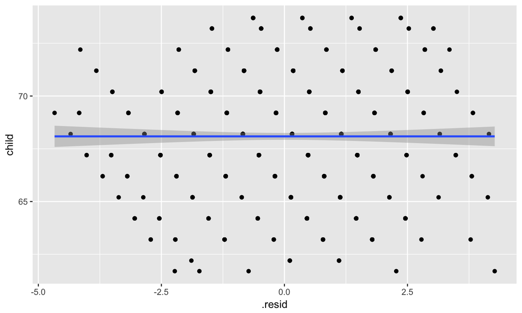

```r
ggplot(galton.data.1, aes(x=.resid, y=child)) +
    geom_point() +
    geom_smooth(method=lm)
```

## and yhat

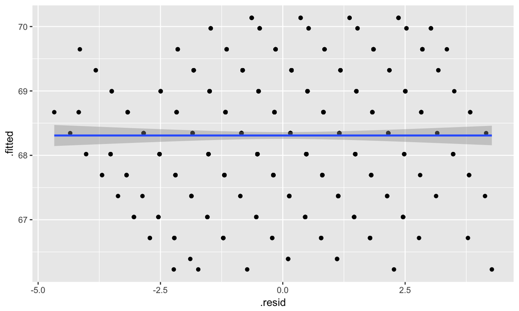

```r
ggplot(galton.data.1, aes(x=.resid, y=.fitted)) +
    geom_point() +
    geom_smooth(method=lm)
```

## r(fitted and X) = 1

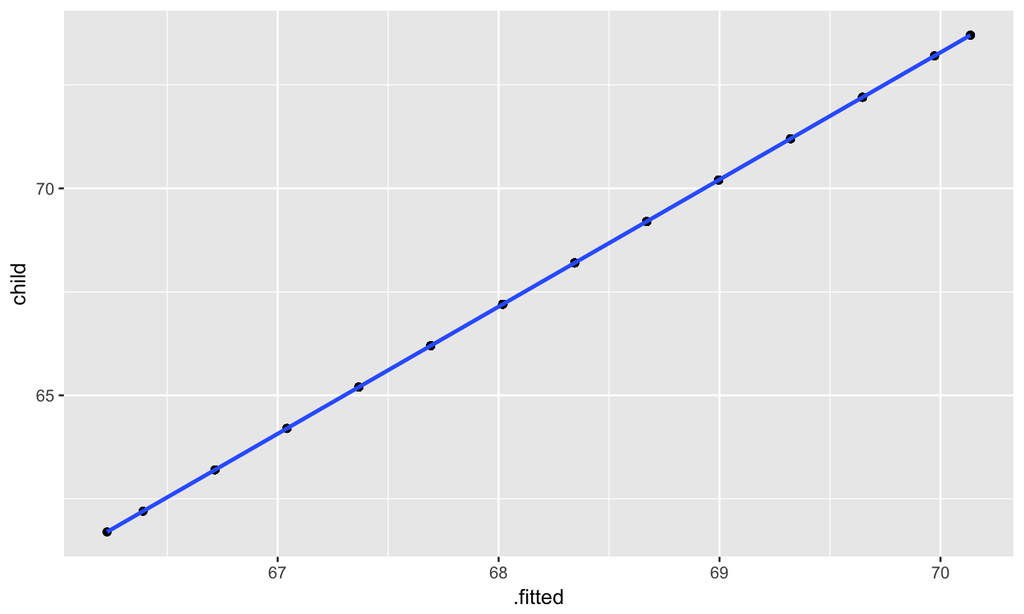

```r
ggplot(galton.data.1, aes(x=.fitted, y=child)) +
    geom_point() +
    geom_smooth(method=lm)
```

## Statistical Inference

- The way the world is = our model + error
- How good is our model? Does it “fit” the data well?

## Partitioning variance in Y

- Consider the case with no correlation btw X and Y \[ \hat{Y} = \bar{Y} + r_{xy} \frac{s_{y}}{s_{x}}(X-\bar{X}) \] \[ \hat{Y} = \bar{Y} \]

## Partitioning variance in Y

- To the extent that we can generate different predicted values of Y based on the values of the predictors, we are doing well in our prediction

\[ \sum (Y - \bar{Y})^2 = \sum (\hat{Y} -\bar{Y})^2 + \sum(Y - \hat{Y})^2 \]

- SS total = SS regression + SS residual (or error)

## Coefficient of Determination

\[ \frac{s_{regression}^2}{s_{y}^2} = \frac{SS_{regression}}{SS_{Y}} = R^2 \]

## Example

```r
summary(fit.1)$r.squared
```

```
## [1] 0.2104629
```

##Example

```r
cor.test(galton.data$parent, galton.data$child)
```

```
##
##  Pearson's product-moment correlation
##
## data:  galton.data$parent and galton.data$child
## t = 15.711, df = 926, p-value < 2.2e-16
## alternative hypothesis: true correlation is not equal to 0
## 95 percent confidence interval:
##  0.4064067 0.5081153
## sample estimates:
##       cor
## 0.4587624
```

## calculating R2

```
## Analysis of Variance Table
##
## Response: parent
##            Df  Sum Sq Mean Sq F value    Pr(>F)
## child       1  623.26  623.26  246.84 < 2.2e-16 ***
## Residuals 926 2338.10    2.52
## ---
## Signif. codes:  0 '***' 0.001 '**' 0.01 '*' 0.05 '.' 0.1 ' ' 1
```

## Computing Sum of Squares

\[ \frac{SS_{regression}}{SS_{Y}} = R^2 \] \[ {SS_{regression}} = R^2({SS_{Y})} \] \[ {SS_{residual}} = SS_{Y} - R^2({SS_{Y})} \]

\[ {SS_{residual}} = (1- R^2){SS_{Y}} \]

## Mean square error (MSE)

- unbiased estimate of error variance
- measure of discrepancy between the data and the model
- the MSE is the variance around the fitted regression line

## residual standard error

MSE = 2.52

```
##
## Call:
## lm(formula = parent ~ child, data = galton.data)
##
## Residuals:
##     Min      1Q  Median      3Q     Max
## -4.6702 -1.1702 -0.1471  1.1324  4.2722
##
## Coefficients:
##             Estimate Std. Error t value Pr(>|t|)
## (Intercept) 46.13535    1.41225   32.67   <2e-16 ***
## child        0.32565    0.02073   15.71   <2e-16 ***
## ---
## Signif. codes:  0 '***' 0.001 '**' 0.01 '*' 0.05 '.' 0.1 ' ' 1
##
## Residual standard error: 1.589 on 926 degrees of freedom
## Multiple R-squared:  0.2105, Adjusted R-squared:  0.2096
## F-statistic: 246.8 on 1 and 926 DF,  p-value: < 2.2e-16
```

## residual standard error/deviation

- aka standard deviation of the residual
- aka standard error of the estimate

\[ \hat{\sigma} \]

- Interpreted in original units (cf R2)
- Standard deviation of Y not accounted by model

## residual standard error/deviation (sigma)

```r
summary(fit.1)$sigma
```

```
## [1] 1.589008
```

```r
psych::describe(galton.data.1$.resid)
```

```
##    vars   n mean   sd median trimmed  mad   min  max range skew kurtosis
## X1    1 928    0 1.59  -0.15    0.02 1.52 -4.67 4.27  8.94 -0.1    -0.17
##      se
## X1 0.05
```

## residual standard error/deviation (sigma)

```r
summary(fit.1)$sigma
```

```
## [1] 1.589008
```

```r
psych::describe(galton.data$parent)
```

```
##    vars   n  mean   sd median trimmed  mad min max range  skew kurtosis
## X1    1 928 68.31 1.79   68.5   68.32 1.48  64  73     9 -0.04     0.05
##      se
## X1 0.06
```

## Why do we care? Let’s simulate to find out

```r
x.1 <- rnorm(1000, 0, 1)
e.1 <- rnorm(1000, 0, 1)
y.1 <- .5 + .55 * x.1 + e.1
d.1 <- data.frame(x.1,y.1)
m.1 <- lm(y.1 ~ x.1, data = d.1)
```

```r
summary(m.1)
```

```
##
## Call:
## lm(formula = y.1 ~ x.1, data = d.1)
##
## Residuals:
##      Min       1Q   Median       3Q      Max
## -2.77787 -0.68030  0.02434  0.65439  2.90506
##
## Coefficients:
##             Estimate Std. Error t value Pr(>|t|)
## (Intercept)  0.50851    0.03123   16.29   <2e-16 ***
## x.1          0.53158    0.03048   17.44   <2e-16 ***
## ---
## Signif. codes:  0 '***' 0.001 '**' 0.01 '*' 0.05 '.' 0.1 ' ' 1
##
## Residual standard error: 0.9874 on 998 degrees of freedom
## Multiple R-squared:  0.2336, Adjusted R-squared:  0.2328
## F-statistic: 304.2 on 1 and 998 DF,  p-value: < 2.2e-16
```

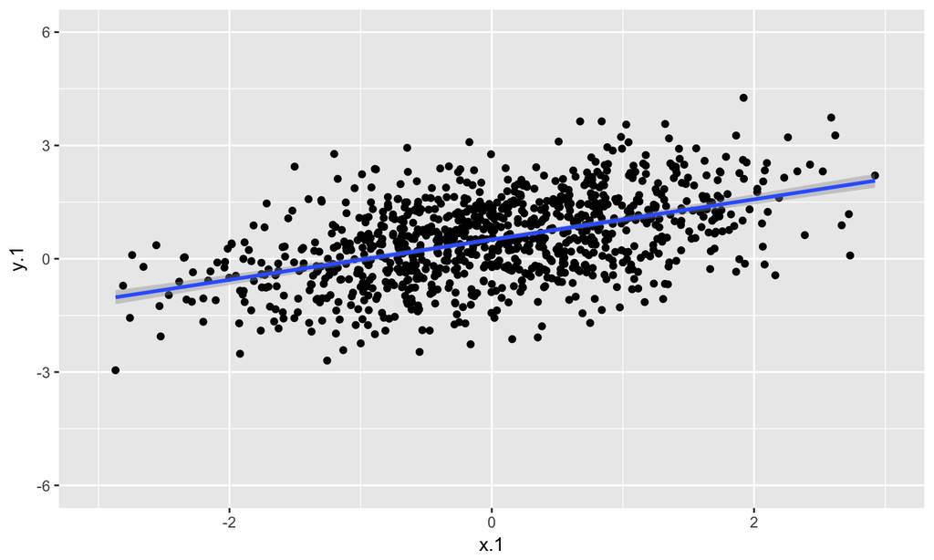

```r
x.2 <- rnorm(1000, 0, 1)
e.2 <- rnorm(1000, 0, 2)
y.2 <- .5 + .55 * x.2 + e.2
d.2 <- data.frame(x.2,y.2)
m.2 <- lm(y.2 ~ x.2, data = d.2)
```

```r
summary(m.2)
```

```
##
## Call:
## lm(formula = y.2 ~ x.2, data = d.2)
##
## Residuals:
##     Min      1Q  Median      3Q     Max
## -6.8546 -1.3303  0.0151  1.3106  6.3196
##
## Coefficients:
##             Estimate Std. Error t value Pr(>|t|)
## (Intercept)  0.52366    0.06277   8.343 2.39e-16 ***
## x.2          0.50258    0.06415   7.835 1.20e-14 ***
## ---
## Signif. codes:  0 '***' 0.001 '**' 0.01 '*' 0.05 '.' 0.1 ' ' 1
##
## Residual standard error: 1.984 on 998 degrees of freedom
## Multiple R-squared:  0.05795,    Adjusted R-squared:  0.057
## F-statistic: 61.39 on 1 and 998 DF,  p-value: 1.196e-14
```

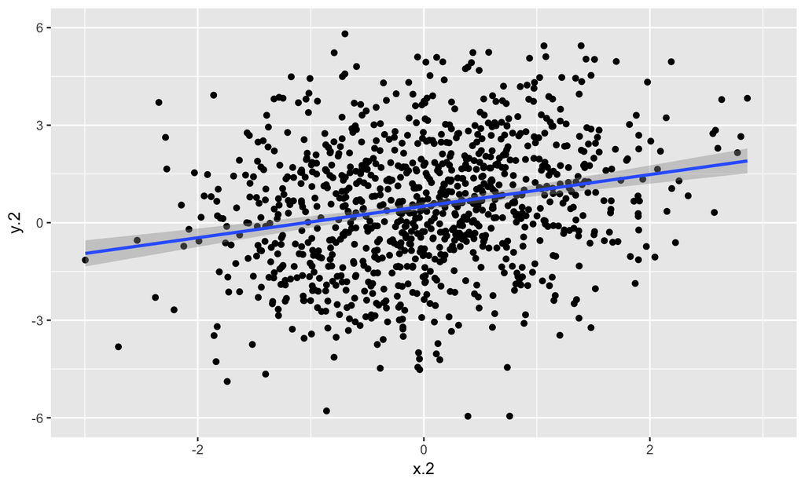

## r2 and residual standard deviation

- two sides of same coin
- one in original units, the other standardized
- R2 can be tricky because the numerator and denominator can be changed in different ways.
- For example if variance in Y is changed but with the same model and residual standard error R2 could decline or increase

## standard errors for b

- represent our uncertainty (noise) in our estimate of the regression coefficient
- different from residual standard error/deviation (but proportional to).
- much like previously we can take our estimate (b) and put confidence regions around it to get an estimate of what could be “possible” if we ran the study again
- (see equation later)

## Inferential tests

## Omnibus test

\[ H_{0}: \rho_{XY}^2= 0 \] \[ H_{1}: \rho_{XY}^2 \neq 0 \]

\[ F = \frac{MS_{regression}}{MS_{residial}} \]

## Regression coefficient

\[ H_{0}: \beta_{XY}= 0 \] \[ H_{1}: \beta_{XY} \neq 0 \]

## What does the regression coefficient test?

- Does X provide any predictive information?
- Does X provide any explanatory power regarding the variability of Y?
- Is the the average value the best guess (i.e., is Y bar equal to the predicted value of Y?)
- Is the regression line flat?
- Are X and Y correlated?

## Regression coefficient

\[ se_{b} = \frac{s_{Y}}{s_{X}}{\sqrt{\frac {1-r_{xy}^2}{n-2}}} \] \[ t(n-2) = \frac{b_{yx}}{se_{b}} \] ** what is standardized equation?

## Intercept

- same idea, more complex se calculation as the calculation depends on how far the X value (here zero) is away from the mean of X
- farther from the mean, less information, thus more uncertainty
- We will come back and see this equation later

## Confidence interval for coefficents

- same equation as we’ve been working with
- estimate plus minus 1.96*se

## Confidence Bands for regression line

[figure not shown]

## Confidence Bands

- Compare mean estimate for height of 70 based on regression vs binning

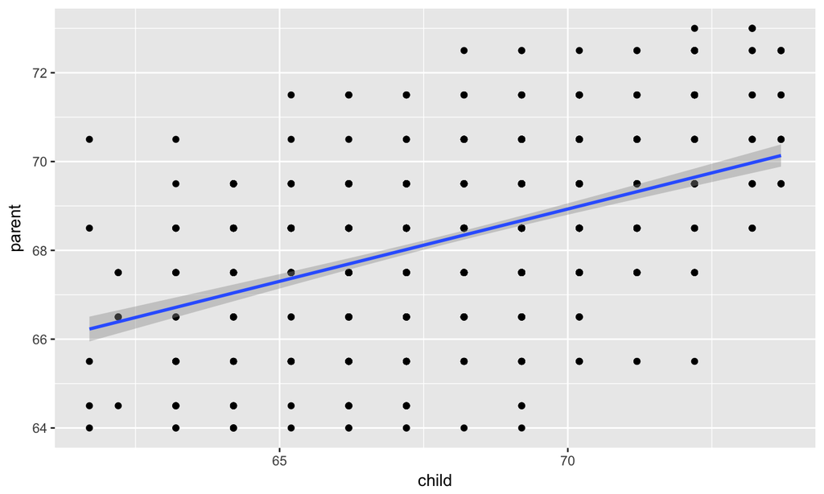

## Confidence Bands

\[ \hat{Y}\pm t_{critical} * se_{residual}*\sqrt{\frac {1}{n}+\frac{(X-\bar{X}bar)^2}{(n-1)s_{X}^2}} \]

## Prediction

- very similar to confidence bands around regressions line
- differences is that is predicting and individual i’s score, not the Y hat for a particular level of X.(A new Yi given X, rather than Ybar given x)
- Because there is greater variation in predicting an individual value rather than a collection of individual values (ie the mean) the prediction band is greater
- Combines unknown variability in 1) the estimated mean (as reflected in se of b) 2) peoples scores around mean (residual standard error)

\[ \hat{Y}\pm t_{critical} * se_{residual}*\sqrt{1+ \frac {1}{n}+\frac{(X-\bar{X}bar)^2}{(n-1)s_{X}^2}} \]

```r
temp_var <- predict(fit.1, interval="prediction")
new_df <- cbind(galton.data, temp_var)
pred <- ggplot(new_df, aes(x=child, y=parent))+
       geom_point() +
  geom_smooth(method=lm,se=TRUE) +
 geom_ribbon(aes(ymin = lwr, ymax = upr),
               fill = "blue", alpha = 0.1)
```

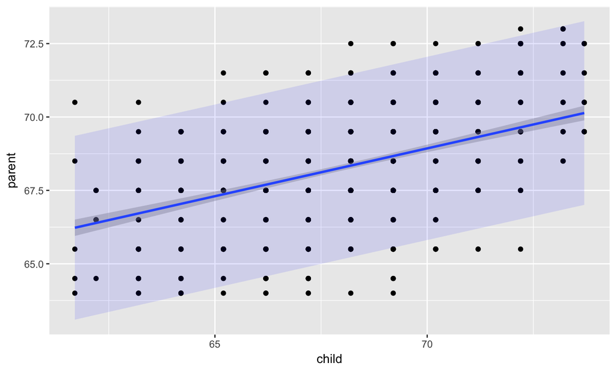

```r
pred
```